# A.N.O.V.A.

Cours E.S.I.E.A. d’estimation à Laval.

Nous souhaitons savoir si le comportement d’une variable quantitative à expliquer est susceptible de changer d’une catégorie à une autre.

```r
#cas équilibrée
ep_3_mois <- c(43,40,41)
ep_6_mois <- c(36,40,39)
ep_12_mois <- c(28,24,33)
ep_24_mois <- c(32,29,32)
```

Pour commencer il faudra calculer la moyenne de chaque échantillon $I$ ayant $J$ observations $\hat{\mu}_I=\frac{1}{J}\sum_{j=1}^J X_{j,I}$

```r
mean_3_mois <- mean(ep_3_mois)
mean_6_mois  <- mean(ep_6_mois)
mean_12_mois  <- mean(ep_12_mois)
mean_24_mois  <- mean(ep_24_mois)
```

Ensuite il faut calculer la moyenne de tout l’effectif $\hat{\mu}$

```r
mean_tot <- mean(c(ep_3_mois,ep_6_mois,ep_12_mois,ep_24_mois))
mean_tot
```

```
[1] 34.75
```

Nous allons ensuite calculer la variance non corrigée de chaque groupe $\sigma^2_I$

```r
var_3_mois <- (sum((ep_3_mois-mean_3_mois)^2))/length(ep_3_mois)
var_3_mois
```

```
[1] 1.556
```

```r
var_6_mois <- (sum((ep_6_mois-mean_6_mois)^2))/length(ep_6_mois)
var_6_mois
```

```
[1] 2.889
```

```r
var_12_mois <- (sum((ep_12_mois-mean_12_mois)^2))/length(ep_12_mois)
var_12_mois
```

```
[1] 13.56
```

```r
var_24_mois <- (sum((ep_24_mois-mean_24_mois)^2))/length(ep_24_mois)
var_24_mois
```

```
[1] 2
```

On liste ensuite les informations suivantes :  
* Nombre d’observations par groupe $J$  
* Nombre de groupes $I$  
* Nombre d’observations $n$

```r
#nb observations par groupe
J=3
#nb groupes
I=4
#nb observations
n=I*J
```

Calculons la variance des écarts à la moyenne: $\frac{1}{I}\sum_{i=1}^{I}(\mu_i - \mu_T)^2$

```r
#variance mean
var_mean <- 1/I*( (mean_3_mois-mean_tot)^2   +   (mean_6_mois-mean_tot)^2   + (mean_12_mois-mean_tot)^2  +  (mean_24_mois-mean_tot)^2    )
var_mean
```

```
[1] 27.85
```

Calculons la variance moyenne :

```r
mean_var <- 1/I*(var_3_mois+var_6_mois+var_12_mois+var_24_mois)
mean_var
```

```
[1] 5
```

Calculons la variance des observations :

```r
var_obsevation = var_mean + mean_var
var_obsevation
```

```
[1] 32.85
```

Calculons la variation totale $SC_T$ telle que $SC_T = SC_F + SC_R$

```r
# variation due au facteur (SC_f)
SC_f = J*( (mean_3_mois-mean_tot)^2   +   (mean_6_mois-mean_tot)^2   + (mean_12_mois-mean_tot)^2  +  (mean_24_mois-mean_tot)^2    )
SC_f
```

```
[1] 334.3
```

```r
# variation résiduelle
SC_r = sum((ep_3_mois -mean_3_mois)^2) + sum((ep_6_mois -mean_6_mois)^2) + sum((ep_12_mois -mean_12_mois)^2) + sum((ep_24_mois -mean_24_mois)^2)
SC_r
```

```
[1] 60
```

```r
# variation totale
SC_tot = SC_f + SC_r
SC_tot
```

```
[1] 394.3
```

Calculons la variance dûe aux facteurs intergroupes $\sigma^2_F = \frac{SC_F}{I-1}$

```r
#variance due au facteur variance intergroupe
var_f = SC_f / (I-1)
var_f
```

```
[1] 111.4
```

Calculons la variance corrigée des moyennes des groupes $\sigma^2_{\text{cor}I} = \frac{\sigma^2_F}{J}$

```r
#variance corrigé des moyennes des groupes
var_cor =  var_f/J
var_cor
```

```
[1] 37.14
```

Calculons la variance résiduelle $\sigma^2_R = \frac{SC_R}{n-I}$

```r
var_r = SC_r / (n-I)
var_r
```

```
[1] 7.5
```

Si H0 vrai, $F_{OBS} = \frac{\sigma^2_F}{\sigma^2_R}$ est une réalisation aléatoire F qui suit une loi de Fisher à $I-1$ degré de liberté au numérateur et (n-I) au dénominateur. [La table est disponible ici :]http://www.ilovestatistics.be/probabilite/tables-F-snedecor.html

```r
F_obs = var_f/var_r
F_obs
```

```
[1] 14.86
```

On peut égalemet utiliser la fonction anvoa() sur R.

On commence par créer un dataframe :

```r
df <- data.frame(valeur=c(ep_3_mois,ep_6_mois,ep_12_mois,ep_24_mois),
                 echantillon = c(replicate(3,"ep_3_mois"),replicate(3,"ep_6_mois"),replicate(3,"ep_12_mois"),replicate(3,"ep_24_mois")))
df$echantillon <- as.factor(df$echantillon)
```

```r
fit <- aov(valeur ~ echantillon, data=df) # y est la variable numérique et A indique les groupes
summary(fit)
```

```
            Df Sum Sq Mean Sq F value Pr(>F)
echantillon  3    334   111.4    14.9 0.0012 **
Residuals    8     60     7.5
---
Signif. codes:  0 ‘***’ 0.001 ‘**’ 0.01 ‘*’ 0.05 ‘.’ 0.1 ‘ ’ 1
```

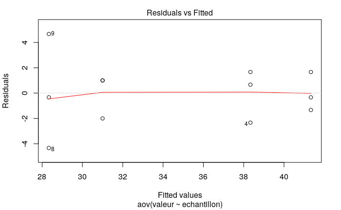

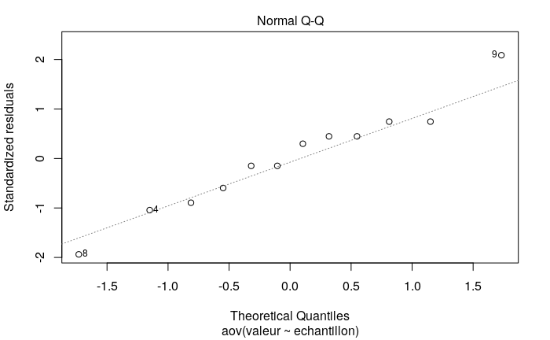

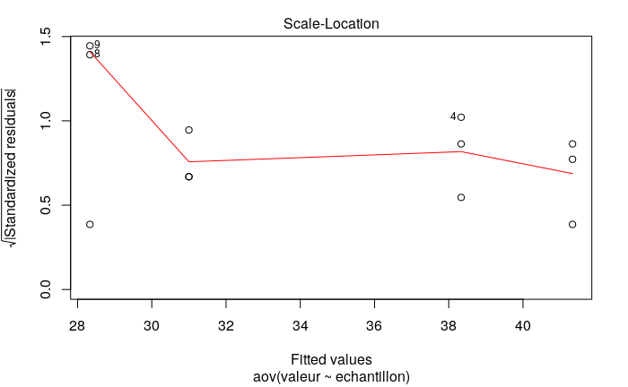

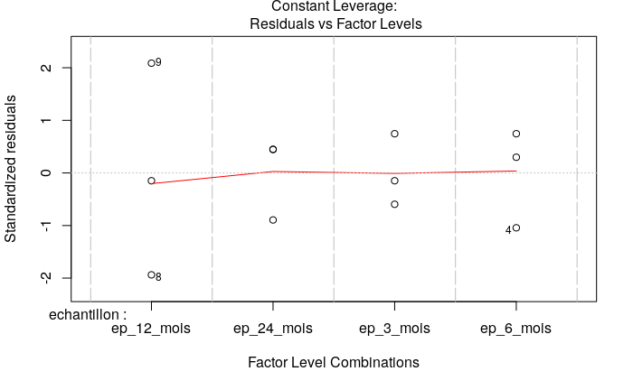

```r
plot(fit)
```

# https://statistique-et-logiciel-r.com/anova-a-2-facteurs-avec-r-tutoriel/